# 4. Binomial Small (n = 5, p = 0.10)

Skewed AND lumpy: two problems at once

Author

Richa Vakharia

```r
source("R/clt_helpers.R")
size <- 5; prob <- 0.10
gen_binom <- function(k) rbinom(k, size = size, prob = prob)
```

## 1 What population am I sampling from?

Each observation is the number of successes in 5 trials with success probability 0.10, from `rbinom(size = 5, prob = 0.1)`. One heads-up on notation: the binomial’s “$n = 5$” is the number of **trials inside one observation**. It’s not my sample size. I’ll call the binomial parameter `size` so I don’t mix them up.

This population is **highly discrete** (values 0 to 5, but really almost always 0 or 1) and **right-skewed**: 59% of the time the value is 0.

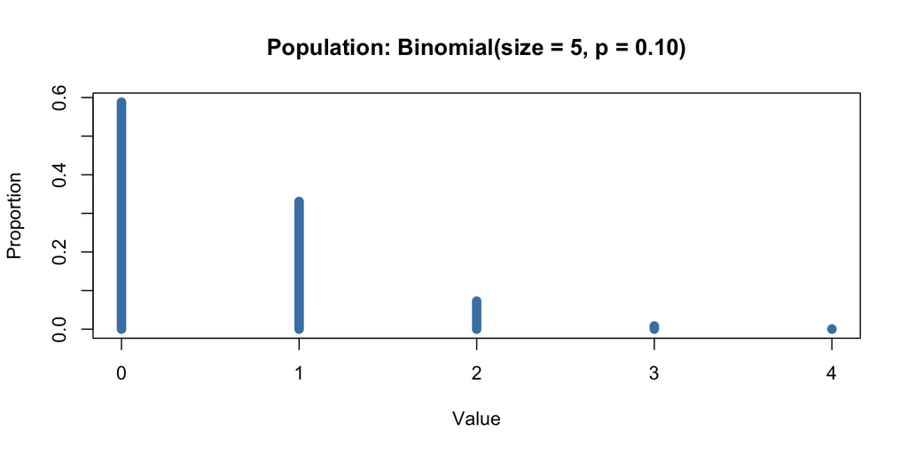

```r
plot_population(gen_binom, "Population: Binomial(size = 5, p = 0.10)", discrete = TRUE)
```

```r
round(dbinom(0:5, size, prob), 4)
```

```
[1] 0.5905 0.3280 0.0729 0.0081 0.0005 0.0000
```

```r
mu    <- size * prob                              # 0.5
sigma <- sqrt(size * prob * (1 - prob))           # sqrt(0.45)
g1    <- (1 - 2 * prob) / sigma                   # skewness
g2    <- (1 - 6 * prob * (1 - prob)) / sigma^2    # excess kurtosis
data.frame(mean = mu, sd = sigma, skewness = g1, excess_kurtosis = g2)
```

```
  mean        sd skewness excess_kurtosis
1  0.5 0.6708204  1.19257        1.022222
```

## 2 What did I expect?

The skewness is 1.193, smaller than the exponential’s 2, so based on skewness alone it should converge faster than the exponential:

```r
predicted_n(g1, g2)
```

```
  from_skewness from_kurtosis prediction
1            23             3         23
```

So my theory-only guess is about $n = 23$. But I expect the discreteness to slow things down, because the mean of $n$ observations can only be a multiple of $1/n$, and most of the probability is piled up on a few values. My real guess is somewhere between 25 and 60.

## 3 Which sample sizes did I investigate?

The standard grid from 1 to 500, with $B = 10,000$ repetitions at each $n$.

## 4 Simulation

```r
sweep  <- run_sweep(function(n) simulate_means(gen_binom, n, B), mu = mu, sigma = sigma)
tab    <- sweep$table
n_star <- chosen_n(tab)
show_table(tab)
```

| n | sim_mean | theo_mean | sim_se | theo_se | se_ratio | skewness | ex_kurt | qq_cor | qq_dist | shapiro_p | normal_enough |
| --- | --- | --- | --- | --- | --- | --- | --- | --- | --- | --- | --- |
| 1 | 0.4987 | 0.5 | 0.67460 | 0.67080 | 1.0060 | 1.21000 | 1.038000 | 0.8403 | 0.47270 | <1e-04 | FALSE |
| 2 | 0.4953 | 0.5 | 0.47160 | 0.47430 | 0.9942 | 0.84960 | 0.510700 | 0.9163 | 0.56820 | <1e-04 | FALSE |
| 3 | 0.4986 | 0.5 | 0.38840 | 0.38730 | 1.0030 | 0.70340 | 0.297900 | 0.9461 | 0.34700 | <1e-04 | FALSE |
| 4 | 0.5017 | 0.5 | 0.33500 | 0.33540 | 0.9988 | 0.57930 | 0.201400 | 0.9622 | 0.23140 | <1e-04 | FALSE |
| 5 | 0.4957 | 0.5 | 0.30050 | 0.30000 | 1.0020 | 0.53910 | 0.165200 | 0.9700 | 0.32680 | <1e-04 | FALSE |
| 6 | 0.4957 | 0.5 | 0.27210 | 0.27390 | 0.9935 | 0.46960 | 0.049260 | 0.9756 | 0.18490 | <1e-04 | FALSE |
| 8 | 0.4987 | 0.5 | 0.23780 | 0.23720 | 1.0030 | 0.43870 | 0.264300 | 0.9822 | 0.21200 | <1e-04 | FALSE |
| 10 | 0.4961 | 0.5 | 0.21200 | 0.21210 | 0.9994 | 0.35900 | -0.031070 | 0.9862 | 0.22550 | <1e-04 | FALSE |
| 12 | 0.4979 | 0.5 | 0.19160 | 0.19360 | 0.9896 | 0.32270 | 0.042130 | 0.9888 | 0.21110 | <1e-04 | FALSE |
| 15 | 0.4986 | 0.5 | 0.17240 | 0.17320 | 0.9956 | 0.36040 | 0.212900 | 0.9900 | 0.14600 | <1e-04 | FALSE |
| 20 | 0.4985 | 0.5 | 0.14930 | 0.15000 | 0.9953 | 0.28890 | 0.200700 | 0.9930 | 0.09627 | <1e-04 | FALSE |
| 25 | 0.5002 | 0.5 | 0.13440 | 0.13420 | 1.0020 | 0.26420 | 0.062070 | 0.9942 | 0.11670 | <1e-04 | FALSE |
| 30 | 0.4995 | 0.5 | 0.12430 | 0.12250 | 1.0150 | 0.22530 | 0.047680 | 0.9954 | 0.13280 | <1e-04 | FALSE |
| 35 | 0.5003 | 0.5 | 0.11230 | 0.11340 | 0.9905 | 0.17980 | 0.060320 | 0.9963 | 0.07937 | <1e-04 | FALSE |
| 40 | 0.4998 | 0.5 | 0.10610 | 0.10610 | 1.0010 | 0.18830 | 0.028960 | 0.9966 | 0.07533 | <1e-04 | FALSE |
| 45 | 0.4995 | 0.5 | 0.10160 | 0.10000 | 1.0160 | 0.19050 | 0.034090 | 0.9969 | 0.10790 | <1e-04 | FALSE |
| 50 | 0.4995 | 0.5 | 0.09512 | 0.09487 | 1.0030 | 0.19940 | 0.091240 | 0.9970 | 0.07520 | <1e-04 | FALSE |
| 60 | 0.5004 | 0.5 | 0.08708 | 0.08660 | 1.0050 | 0.15930 | 0.020150 | 0.9977 | 0.11750 | <1e-04 | FALSE |
| 70 | 0.4992 | 0.5 | 0.07927 | 0.08018 | 0.9886 | 0.16660 | -0.021410 | 0.9978 | 0.07466 | <1e-04 | FALSE |
| 80 | 0.5008 | 0.5 | 0.07488 | 0.07500 | 0.9984 | 0.11780 | 0.007289 | 0.9984 | 0.04719 | <1e-04 | TRUE |
| 90 | 0.4997 | 0.5 | 0.07100 | 0.07071 | 1.0040 | 0.11410 | 0.021420 | 0.9985 | 0.06816 | <1e-04 | TRUE |
| 100 | 0.5004 | 0.5 | 0.06719 | 0.06708 | 1.0020 | 0.11960 | 0.048920 | 0.9986 | 0.09018 | <1e-04 | TRUE |
| 125 | 0.4991 | 0.5 | 0.05948 | 0.06000 | 0.9913 | 0.08261 | 0.072710 | 0.9990 | 0.05644 | <1e-04 | TRUE |
| 150 | 0.4997 | 0.5 | 0.05452 | 0.05477 | 0.9953 | 0.08189 | -0.035770 | 0.9991 | 0.05796 | <1e-04 | TRUE |
| 200 | 0.4998 | 0.5 | 0.04755 | 0.04743 | 1.0020 | 0.08609 | -0.004352 | 0.9993 | 0.05831 | <1e-04 | TRUE |
| 300 | 0.5002 | 0.5 | 0.03901 | 0.03873 | 1.0070 | 0.09590 | 0.005744 | 0.9994 | 0.02924 | <1e-04 | TRUE |
| 500 | 0.4995 | 0.5 | 0.02990 | 0.03000 | 0.9967 | 0.03771 | -0.024870 | 0.9997 | 0.02530 | 0.029 | TRUE |

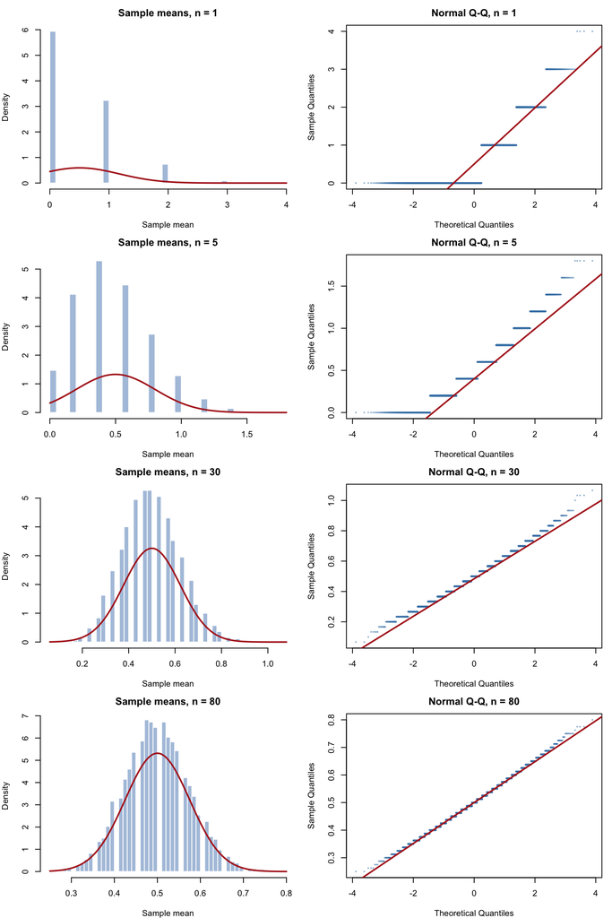

```r
plot_sampling(sweep, c(1, 5, 30, n_star), mu = mu, sigma = sigma)
```

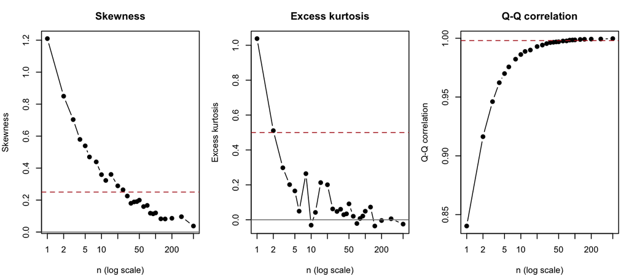

```r
plot_convergence(tab)
```

## 5 Theory vs. simulation

- **Mean:** all simulated means are within 0.005 of 0.5.
- **Standard error:** simulated SE / $(\sigma/\sqrt n)$ ranged from 0.989 to 1.016.
- **Shape:** skewness first drops below 0.25 at $n = 30$, close to the theory prediction of 23.

## 6 When is it approximately normal?

$$\boxed{n = 80}$$

This is a lot bigger than the skewness-only prediction. Looking at the table, skewness and kurtosis were both fine by around $n = 30$, but the **Q-Q correlation** didn’t stay above 0.998 until $n = 80$. The Q-Q plots show why: even at $n = 30$ the points form visible horizontal steps, because the sample mean can only be $0, 1/30, 2/30, \dots$ and a lot of samples tie at the same values.

So for this population there are really two separate problems: skewness (which theory handles well) and discreteness (which theory based on moments doesn’t capture at all).

## 7 What surprised me?

```r
save_results("Binomial Small (5, 0.1)", tab, n_star,
             "Skewness fine by ~30 but discreteness keeps Q-Q plot stair-stepped")
```